# Microplastics Intercalibration Study Data Analysis: Matrix Comparisons, Nile Red

Southern California Coastal Water Research Project, University of Toronto & State Water Resources Control Board of California

16 May, 2022

[figure not shown]

# 1 Spiking Summary

Average Number of Spiked Particles per Sample

| Matrix | Plastic? | Number of Spiked Particles | Standard Deviation |
| --- | --- | --- | --- |
| Clean Water | N | 80.09 | 3.46 |
| Clean Water | Y | 536.49 | 157.03 |
| Dirty Water | N | 80.19 | 0.54 |
| Dirty Water | Y | 117.81 | 1.20 |
| Fish Tissue | N | 80.84 | 1.15 |
| Fish Tissue | Y | 584.62 | 26.99 |
| Sediment | N | 80.95 | 4.03 |
| Sediment | Y | 590.90 | 2.05 |

Average Number of Spiked Particles per Sample by Size Fraction

| Matrix | Plastic? | Size Fraction | Number of Spiked Particles | Standard Deviation |
| --- | --- | --- | --- | --- |
| Clean Water | N | >500 µm | 80.09 | 3.46 |
| Clean Water | Y | >500 µm | 43.96 | 5.00 |
| Clean Water | Y | 1-20 µm | 316.80 | 92.51 |
| Clean Water | Y | 20-212 µm | 114.58 | 45.48 |
| Clean Water | Y | 212-500 µm | 61.15 | 17.46 |
| Dirty Water | N | >500 µm | 80.19 | 0.54 |
| Dirty Water | Y | >500 µm | 46.85 | 0.46 |
| Dirty Water | Y | 212-500 µm | 70.95 | 0.81 |
| Fish Tissue | N | >500 µm | 80.84 | 1.15 |
| Fish Tissue | Y | >500 µm | 46.28 | 0.57 |
| Fish Tissue | Y | 1-20 µm | 360.00 | 24.24 |
| Fish Tissue | Y | 20-212 µm | 108.96 | 7.85 |
| Fish Tissue | Y | 212-500 µm | 69.38 | 0.27 |
| Sediment | N | >500 µm | 80.95 | 4.03 |
| Sediment | Y | >500 µm | 45.22 | 0.56 |
| Sediment | Y | 1-20 µm | 360.00 | 0.00 |
| Sediment | Y | 20-212 µm | 113.36 | 1.91 |
| Sediment | Y | 212-500 µm | 72.32 | 0.13 |

Average Number of Spiked Particles per Sample by Morphology

| Matrix | Plastic? | Morphology | Number of Spiked Particles | Standard Deviation |
| --- | --- | --- | --- | --- |
| Clean Water | N | Fiber | 60.07 | 3.45 |
| Clean Water | N | Fragment | 20.03 | 0.16 |
| Clean Water | Y | Fiber | 20.11 | 1.01 |
| Clean Water | Y | Fragment | 472.79 | 155.42 |
| Clean Water | Y | Sphere | 43.86 | 2.35 |
| Dirty Water | N | Fiber | 60.19 | 0.54 |
| Dirty Water | N | Fragment | 20.00 | 0.00 |
| Dirty Water | Y | Fiber | 20.05 | 0.23 |
| Dirty Water | Y | Fragment | 50.50 | 0.00 |
| Dirty Water | Y | Sphere | 47.25 | 1.19 |
| Fish Tissue | N | Fiber | 60.60 | 0.90 |
| Fish Tissue | N | Fragment | 20.24 | 0.52 |
| Fish Tissue | Y | Fiber | 20.20 | 0.49 |
| Fish Tissue | Y | Fragment | 519.46 | 27.02 |
| Fish Tissue | Y | Sphere | 44.96 | 0.42 |
| Sediment | N | Fiber | 60.73 | 1.55 |
| Sediment | N | Fragment | 20.56 | 2.63 |
| Sediment | Y | Fiber | 20.18 | 0.54 |
| Sediment | Y | Fragment | 523.86 | 1.91 |
| Sediment | Y | Sphere | 46.85 | 0.22 |

Average Number of Spiked Particles per Sample by Morphology Within Size Fraction

| Matrix | Plastic? | Morphology | Size Fraction | Number of Spiked Particles | Standard Deviation |
| --- | --- | --- | --- | --- | --- |
| Clean Water | N | Fiber | >500 µm | 60.07 | 3.45 |
| Clean Water | N | Fragment | >500 µm | 20.03 | 0.16 |
| Clean Water | Y | Fiber | >500 µm | 20.11 | 1.01 |
| Clean Water | Y | Fragment | >500 µm | 5.00 | 0.00 |
| Clean Water | Y | Fragment | 1-20 µm | 316.80 | 92.51 |
| Clean Water | Y | Fragment | 20-212 µm | 114.58 | 45.48 |
| Clean Water | Y | Fragment | 212-500 µm | 45.50 | 0.00 |
| Clean Water | Y | Sphere | >500 µm | 20.01 | 2.06 |
| Clean Water | Y | Sphere | 212-500 µm | 23.84 | 0.76 |
| Dirty Water | N | Fiber | >500 µm | 60.19 | 0.54 |
| Dirty Water | N | Fragment | >500 µm | 20.00 | 0.00 |
| Dirty Water | Y | Fiber | >500 µm | 20.05 | 0.23 |
| Dirty Water | Y | Fragment | >500 µm | 5.00 | 0.00 |
| Dirty Water | Y | Fragment | 212-500 µm | 45.50 | 0.00 |
| Dirty Water | Y | Sphere | >500 µm | 21.80 | 0.40 |
| Dirty Water | Y | Sphere | 212-500 µm | 25.45 | 0.81 |
| Fish Tissue | N | Fiber | >500 µm | 60.60 | 0.90 |
| Fish Tissue | N | Fragment | >500 µm | 20.24 | 0.52 |
| Fish Tissue | Y | Fiber | >500 µm | 20.20 | 0.49 |
| Fish Tissue | Y | Fragment | >500 µm | 5.00 | 0.00 |
| Fish Tissue | Y | Fragment | 1-20 µm | 360.00 | 24.24 |
| Fish Tissue | Y | Fragment | 20-212 µm | 108.96 | 7.85 |
| Fish Tissue | Y | Fragment | 212-500 µm | 45.50 | 0.00 |
| Fish Tissue | Y | Sphere | >500 µm | 21.08 | 0.34 |
| Fish Tissue | Y | Sphere | 212-500 µm | 23.88 | 0.27 |
| Sediment | N | Fiber | >500 µm | 60.73 | 1.55 |
| Sediment | N | Fragment | >500 µm | 20.56 | 2.63 |
| Sediment | Y | Fiber | >500 µm | 20.18 | 0.54 |
| Sediment | Y | Fragment | >500 µm | 5.00 | 0.00 |
| Sediment | Y | Fragment | 1-20 µm | 360.00 | 0.00 |
| Sediment | Y | Fragment | 20-212 µm | 113.36 | 1.91 |
| Sediment | Y | Fragment | 212-500 µm | 45.50 | 0.00 |
| Sediment | Y | Sphere | >500 µm | 20.03 | 0.18 |
| Sediment | Y | Sphere | 212-500 µm | 26.82 | 0.13 |

# 2 Counts

The following section describes data as absolute particle counts that were reported in each sample. Note that Dirty Water samples were not spiked with any particles less than 212µm and are therefore distinct from the other matrices.

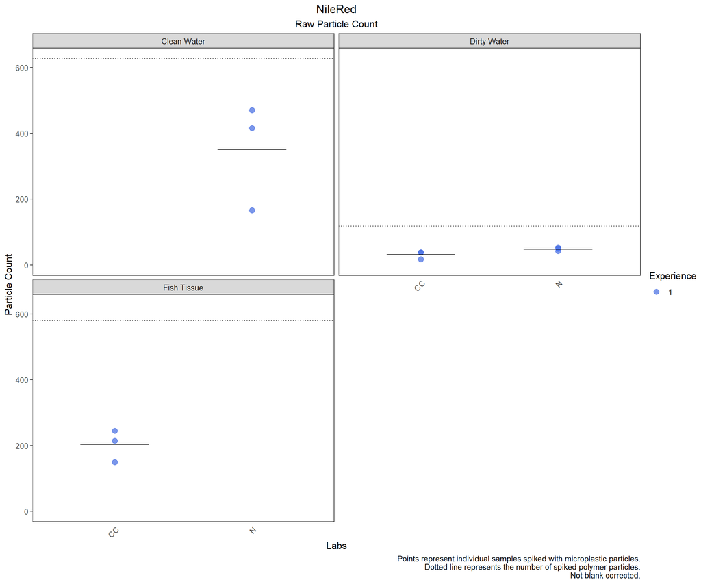

Raw Particle Count. Summary statistics by sample (n = 1-3 samples). Not blank corrected.

| Matrix | Lab ID | Sample ID | Total Particles |
| --- | --- | --- | --- |
| Dirty Water | N | N_DW_1 | 42 |
| Dirty Water | N | N_DW_2 | 50 |
| Dirty Water | N | N_DW_3 | 53 |
| Dirty Water | CC | CC_DW_1 | 17 |
| Dirty Water | CC | CC_DW_3 | 38 |
| Dirty Water | CC | CC_DW_2 | 39 |
| Fish Tissue | CC | CC_FT_1 | 214 |
| Fish Tissue | CC | CC_FT_3 | 245 |
| Fish Tissue | CC | CC_FT_2 | 150 |
| Clean Water | N | N_CW_1 | 166 |
| Clean Water | N | N_CW_2 | 416 |
| Clean Water | N | N_CW_3 | 470 |

[figure not shown]

Raw Particle Count. Summary statistics by laboratory (n = 1-3 samples). Not blank corrected.

| Matrix | Lab ID | Mean | Median | SD | Min | Max |
| --- | --- | --- | --- | --- | --- | --- |
| Clean Water | N | 350.67 | 416 | 162.19 | 166 | 470 |
| Dirty Water | CC | 31.33 | 38 | 12.42 | 17 | 39 |
| Dirty Water | N | 48.33 | 50 | 5.69 | 42 | 53 |
| Fish Tissue | CC | 203.00 | 214 | 48.45 | 150 | 245 |

Raw Particle Count. Global summary statistics. Not blank corrected.

| Matrix | Mean | Median | SD | Min | Max |
| --- | --- | --- | --- | --- | --- |
| Clean Water | 350.67 | 350.67 | NA | 350.67 | 350.67 |
| Dirty Water | 39.83 | 39.83 | 12.02 | 31.33 | 48.33 |
| Fish Tissue | 203.00 | 203.00 | NA | 203.00 | 203.00 |

# 3 Clean Water, Fish Tissue and Sediment Comparisons

Clean Water, Fish Tissue and Sediment samples were spiked with the same materials. Therefore, comparisons may be made for all particle types. Matrix comparisons including dirty water are included in later sections, but only for particle types >212 µm.

## 3.1 Recovery

The following plots display the recovery (reported count/spiked count (%)) obtained from microscopy with nile red. **Reported particle characteristics must match expected particle characteristics of the spiking materials to count towards recovery estimations.** For example, the colors of polymer spiking materials are defined as white, orange, blue, clear and green. Colors outside of these definitions are not included in this section (see Counts).

The dotted line is at 100% and the grey area represents the mean RSD for each given category. The data are **not** blank corrected.

Recovery in this section is estimated based on a single particle characteristic. For example, if the sample was spiked with 10 green particles and 8 green particles were recovered, recovery is estimated as 80% regardless of whether or not the shape or size fraction also matches the spiking material. More restrictive recovery analysis are reported later on in this document.

### 3.1.1 Total

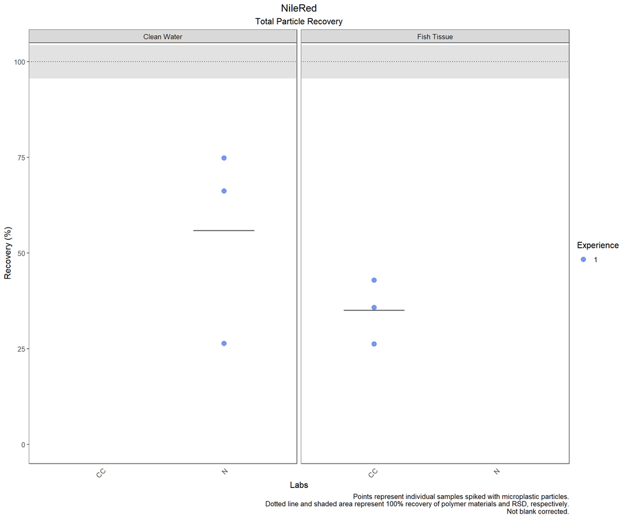

[figure not shown]

NileRed: Total Particle Recovery. Summary statistics by sample (n = 1-3 samples). Not blank corrected.

| Matrix | Lab ID | Sample ID | Recovery |
| --- | --- | --- | --- |
| Clean Water | N | N_CW_1 | 26.45 |
| Clean Water | N | N_CW_2 | 66.27 |
| Clean Water | N | N_CW_3 | 74.88 |
| Fish Tissue | CC | CC_FT_1 | 35.85 |
| Fish Tissue | CC | CC_FT_2 | 26.28 |
| Fish Tissue | CC | CC_FT_3 | 42.93 |

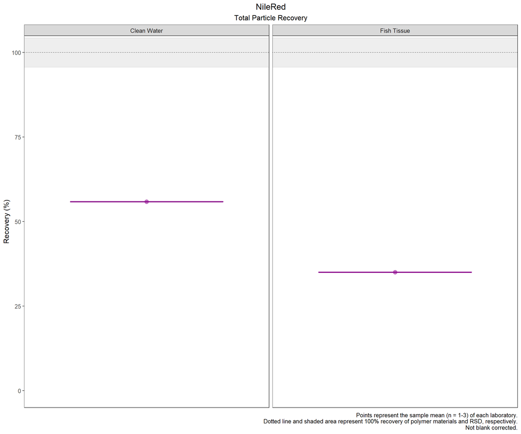

NileRed: Total Particle Recovery. Summary statistics by laboratory (n = 1-3 samples). Not blank corrected.

| Matrix | Lab ID | Mean (%) | Median (%) | SD (%) | Min (%) | Max (%) |
| --- | --- | --- | --- | --- | --- | --- |
| Fish Tissue | CC | 35.02 | 35.85 | 8.35 | 26.28 | 42.93 |
| Clean Water | N | 55.87 | 66.27 | 25.84 | 26.45 | 74.88 |

NileRed: Total Particle Recovery. Summary statistics across all laboratories. Not blank corrected.

| Matrix | Mean (%) | Median (%) | SD (%) | Min (%) | Max (%) |
| --- | --- | --- | --- | --- | --- |
| Fish Tissue | 35.02 | 35.02 | NA | 35.02 | 35.02 |
| Clean Water | 55.87 | 55.87 | NA | 55.87 | 55.87 |

### 3.1.2 Size Fraction

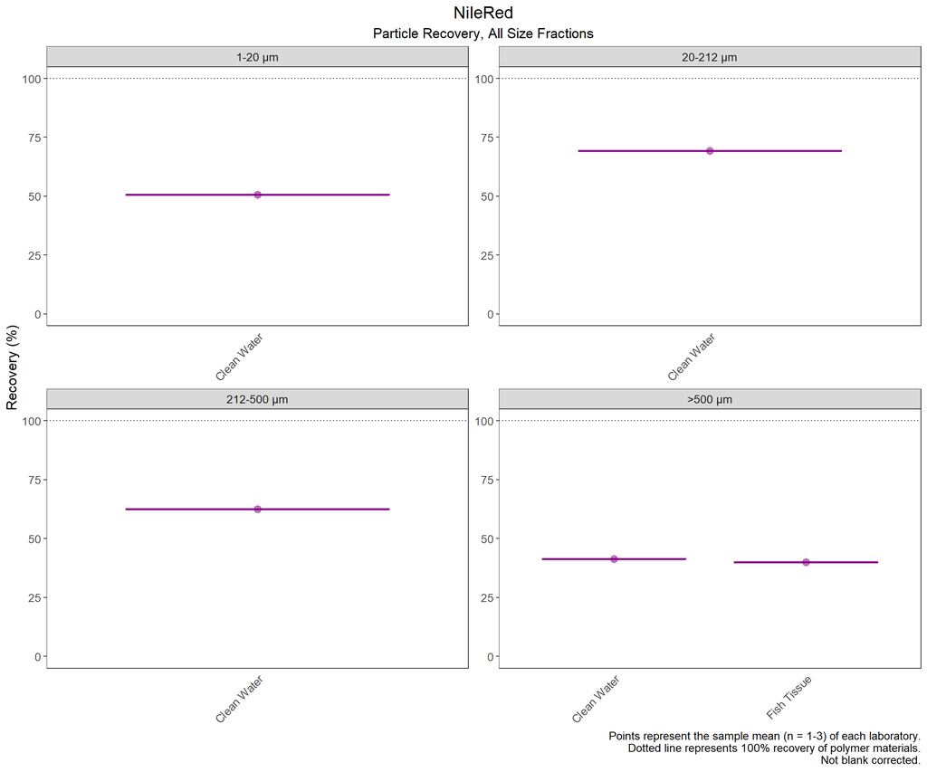

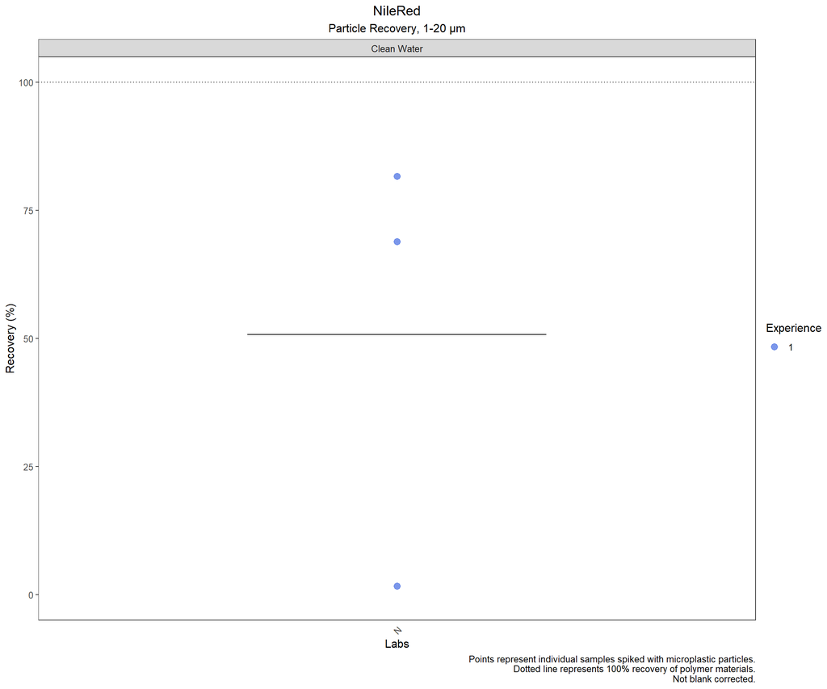

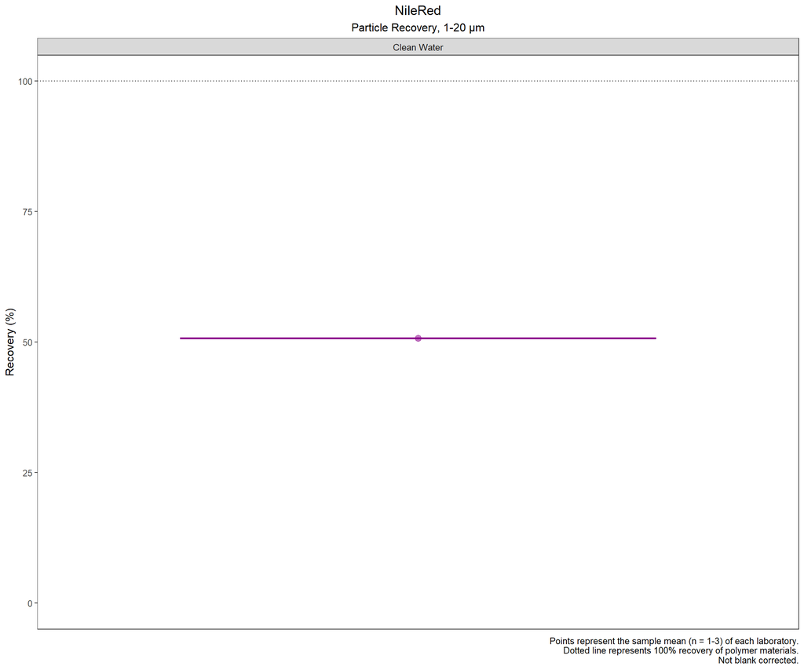

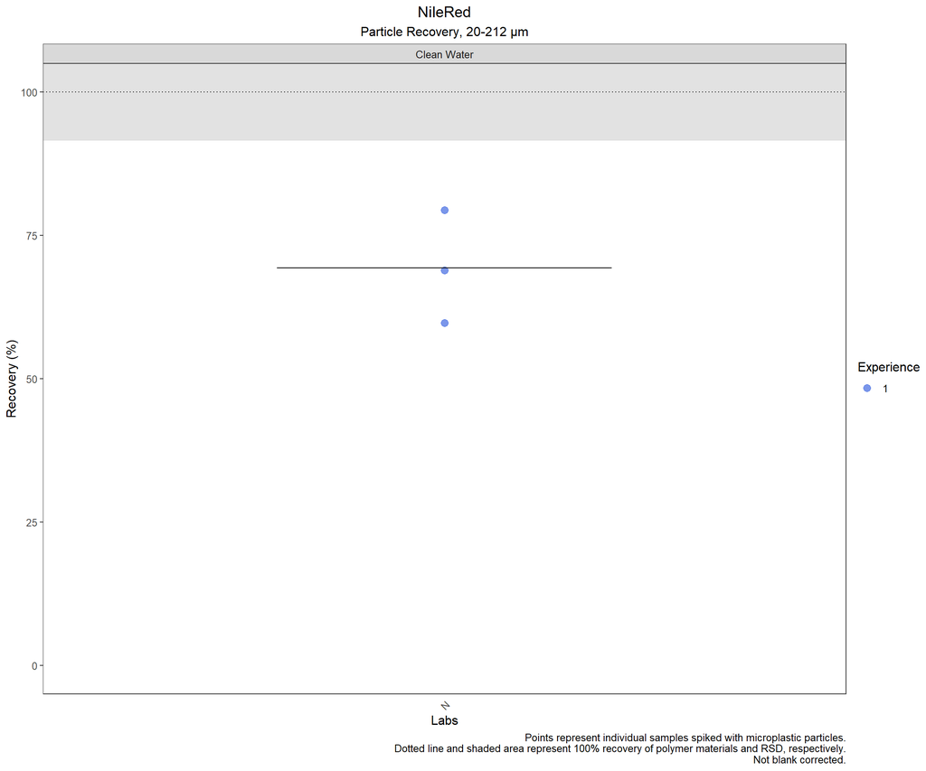

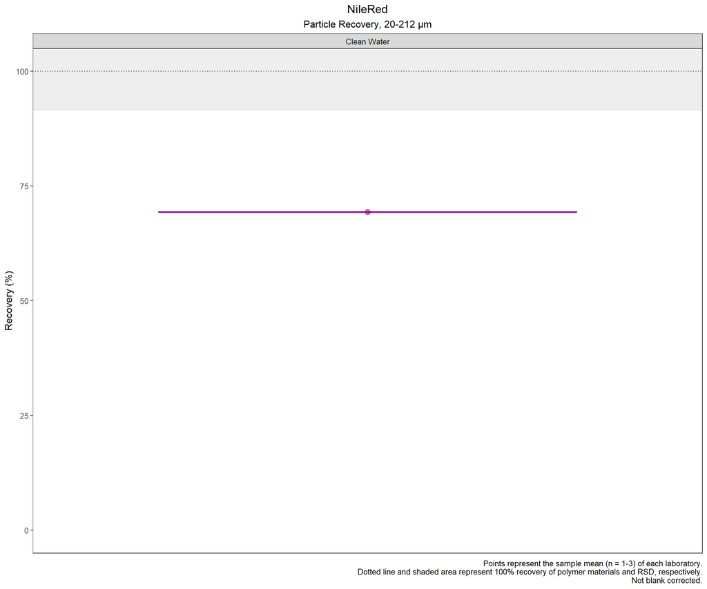

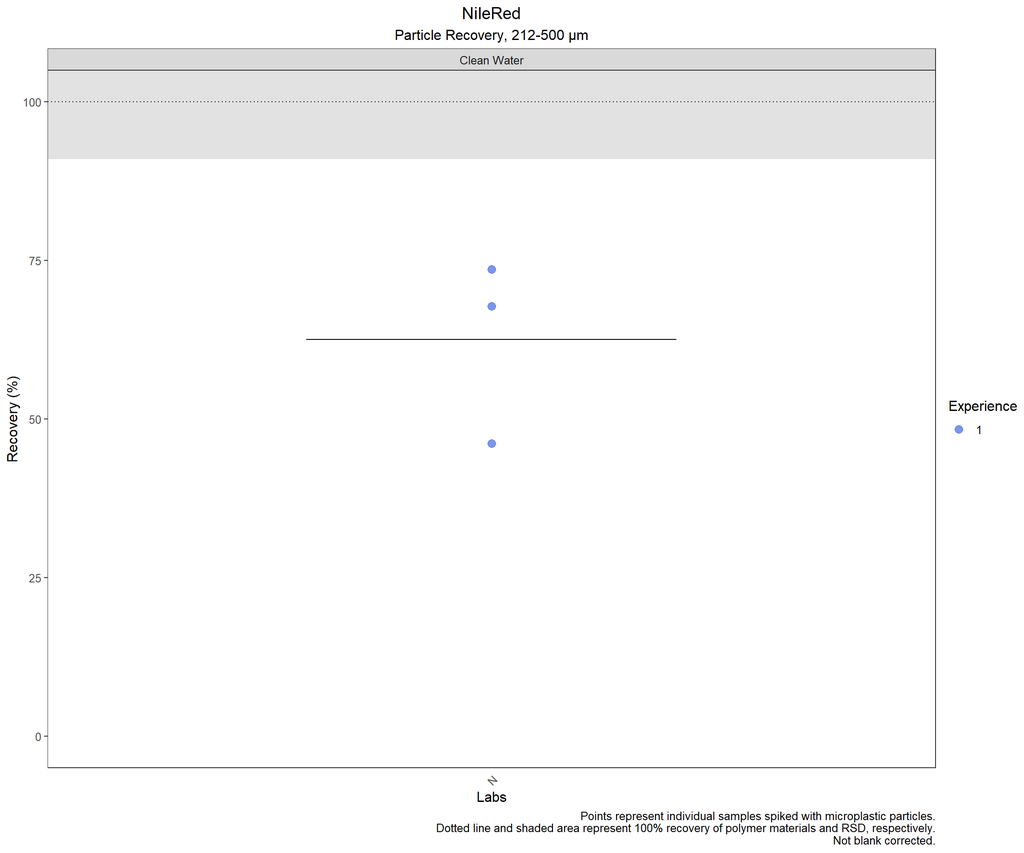

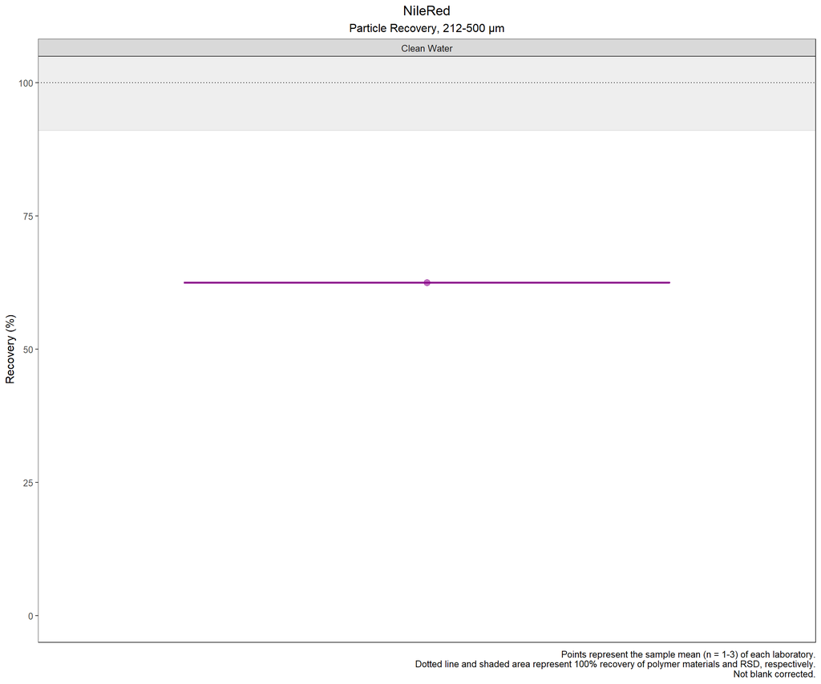

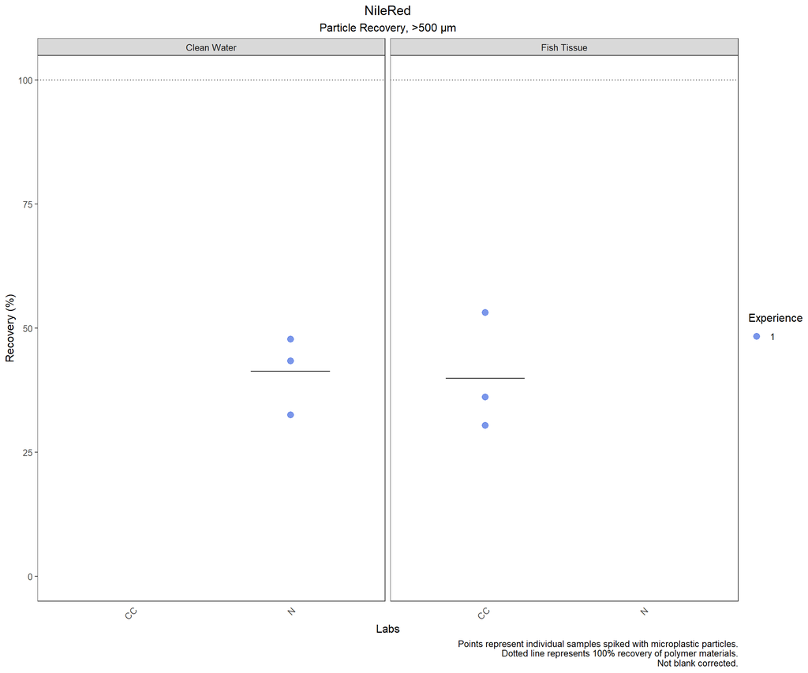

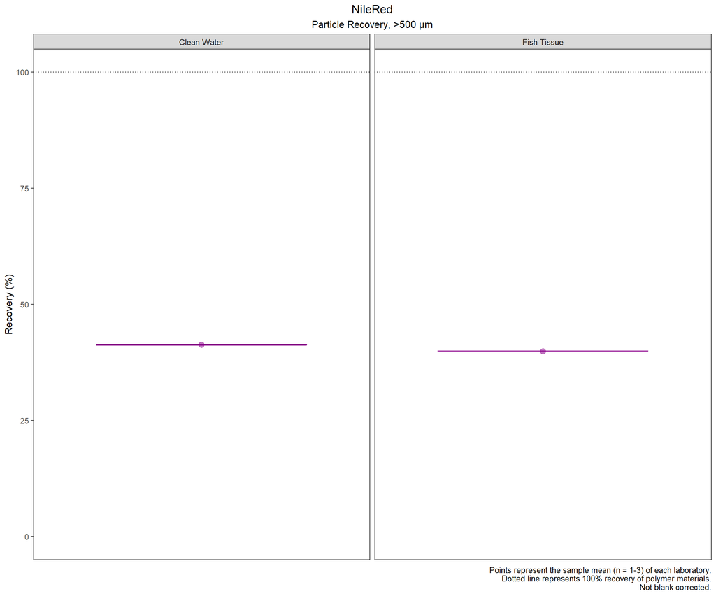

NileRed: Total Particle Recovery by Size Fraction. Summary statistics by sample (n = 1-3 samples). Not blank corrected.

| Matrix | Lab ID | Sample ID | Size Fraction | Recovery |
| --- | --- | --- | --- | --- |
| Clean Water | N | N_CW_1 | >500 µm | 47.83 |
| Clean Water | N | N_CW_1 | 1-20 µm | 1.67 |
| Clean Water | N | N_CW_1 | 20-212 µm | 59.71 |
| Clean Water | N | N_CW_1 | 212-500 µm | 67.82 |
| Clean Water | N | N_CW_2 | >500 µm | 32.61 |
| Clean Water | N | N_CW_2 | 1-20 µm | 68.89 |
| Clean Water | N | N_CW_2 | 20-212 µm | 79.40 |
| Clean Water | N | N_CW_2 | 212-500 µm | 46.18 |
| Clean Water | N | N_CW_3 | >500 µm | 43.48 |
| Clean Water | N | N_CW_3 | 1-20 µm | 81.67 |
| Clean Water | N | N_CW_3 | 20-212 µm | 68.90 |
| Clean Water | N | N_CW_3 | 212-500 µm | 73.59 |
| Fish Tissue | CC | CC_FT_1 | >500 µm | 30.43 |
| Fish Tissue | CC | CC_FT_2 | >500 µm | 53.19 |
| Fish Tissue | CC | CC_FT_3 | >500 µm | 36.17 |

NileRed: Total Particle Recovery by Size Fraction. Summary statistics by laboratory (n = 1-3 samples). Not blank corrected.

| Matrix | Lab ID | Size Fraction | Mean (%) | Median (%) | SD (%) | Min (%) | Max (%) |
| --- | --- | --- | --- | --- | --- | --- | --- |
| Fish Tissue | CC | >500 µm | 39.93 | 36.17 | 11.84 | 30.43 | 53.19 |
| Clean Water | N | >500 µm | 41.30 | 43.48 | 7.84 | 32.61 | 47.83 |
| Clean Water | N | 1-20 µm | 50.74 | 68.89 | 42.98 | 1.67 | 81.67 |
| Clean Water | N | 20-212 µm | 69.34 | 68.90 | 9.85 | 59.71 | 79.40 |
| Clean Water | N | 212-500 µm | 62.53 | 67.82 | 14.45 | 46.18 | 73.59 |

NileRed: Total Particle Recovery by Size Fraction. Summary statistics across all laboratories. Not blank corrected.

| Matrix | Size Fraction | Global Mean (%) | Median (%) | SD (%) | Min (%) | Max (%) |
| --- | --- | --- | --- | --- | --- | --- |
| Clean Water | >500 µm | 41.30 | 41.30 | NA | 41.30 | 41.30 |
| Clean Water | 1-20 µm | 50.74 | 50.74 | NA | 50.74 | 50.74 |
| Clean Water | 20-212 µm | 69.34 | 69.34 | NA | 69.34 | 69.34 |
| Clean Water | 212-500 µm | 62.53 | 62.53 | NA | 62.53 | 62.53 |
| Fish Tissue | >500 µm | 39.93 | 39.93 | NA | 39.93 | 39.93 |

### 3.1.3 Morphology

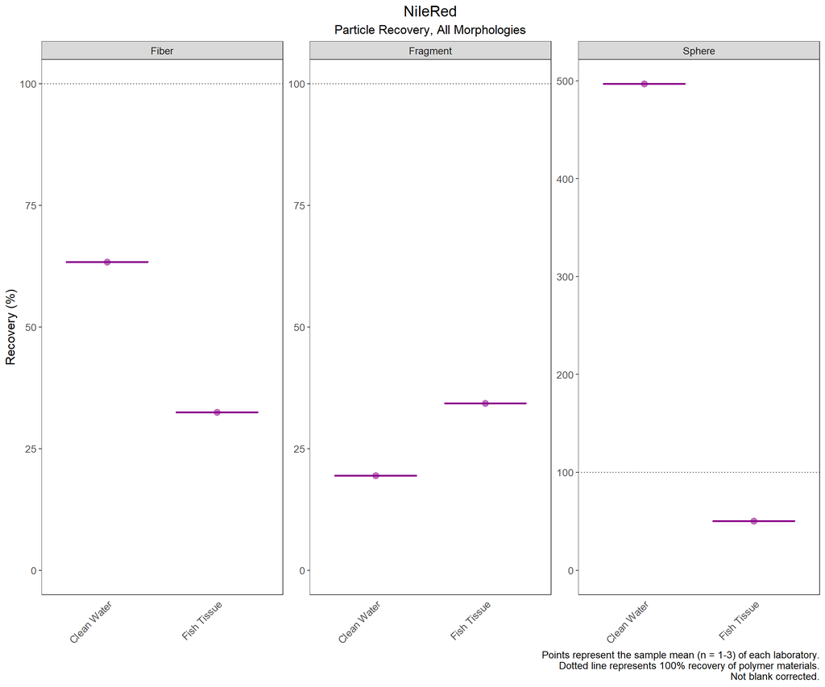

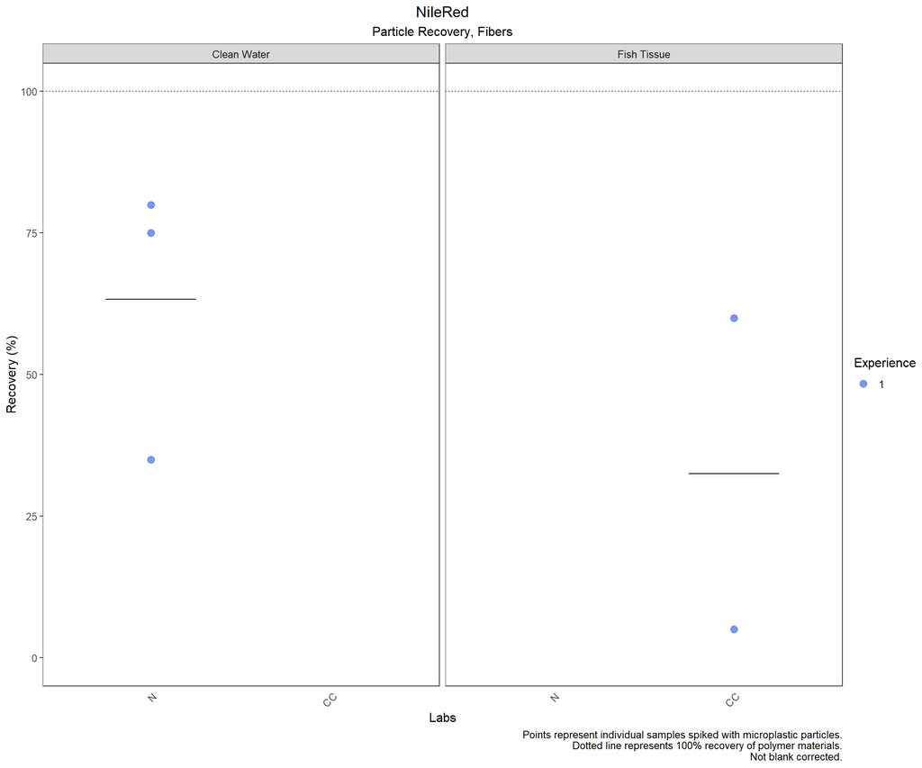

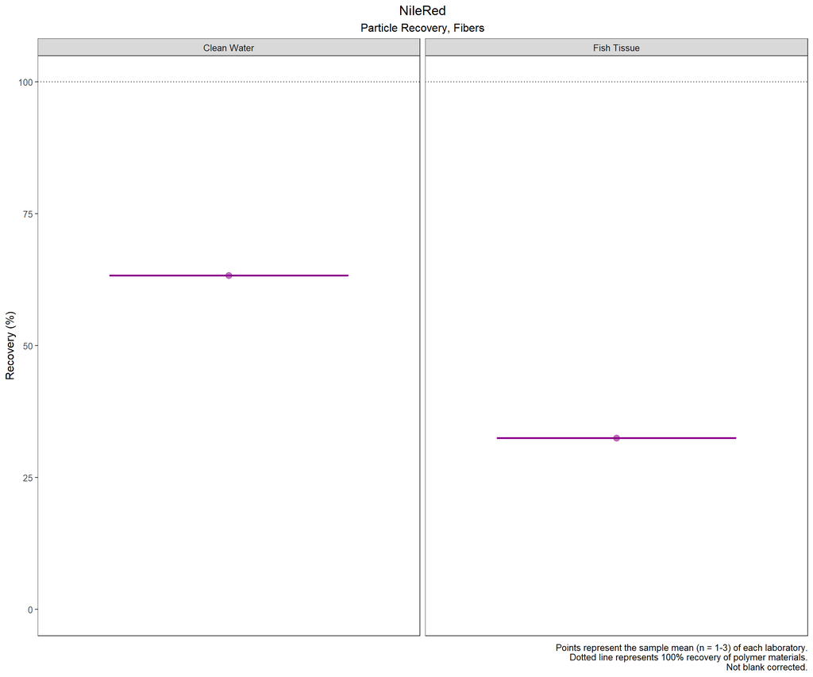

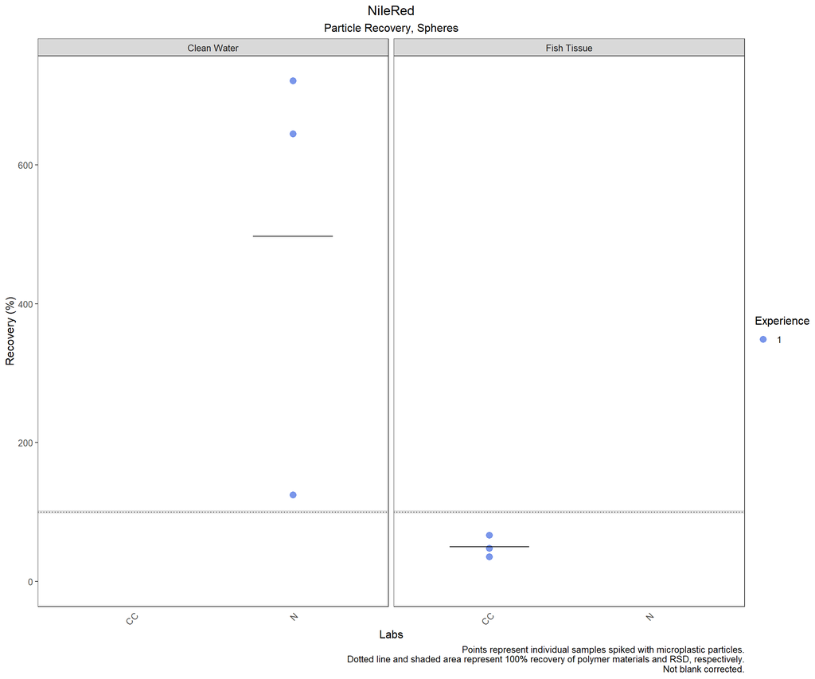

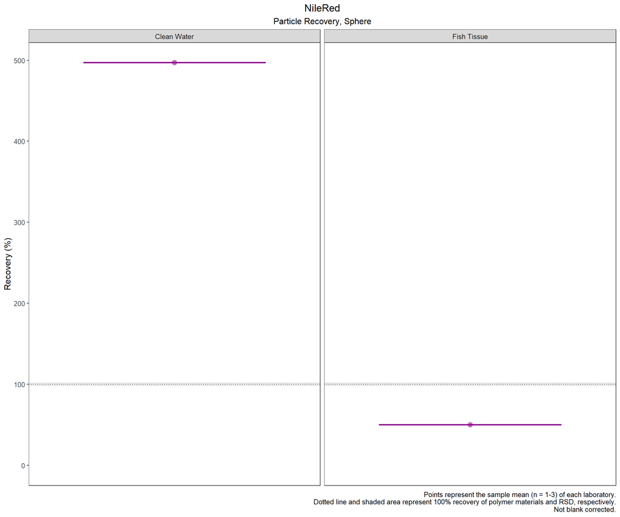

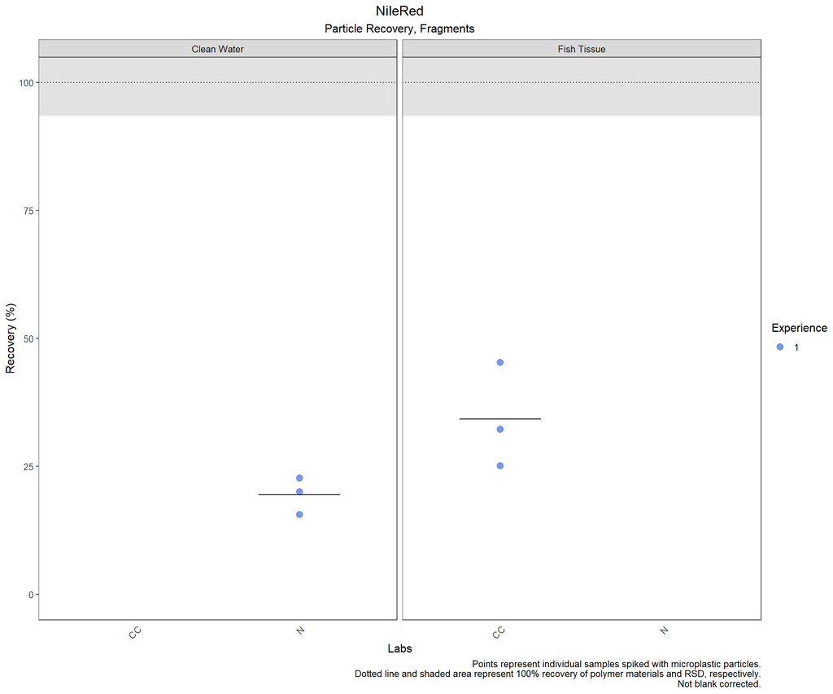

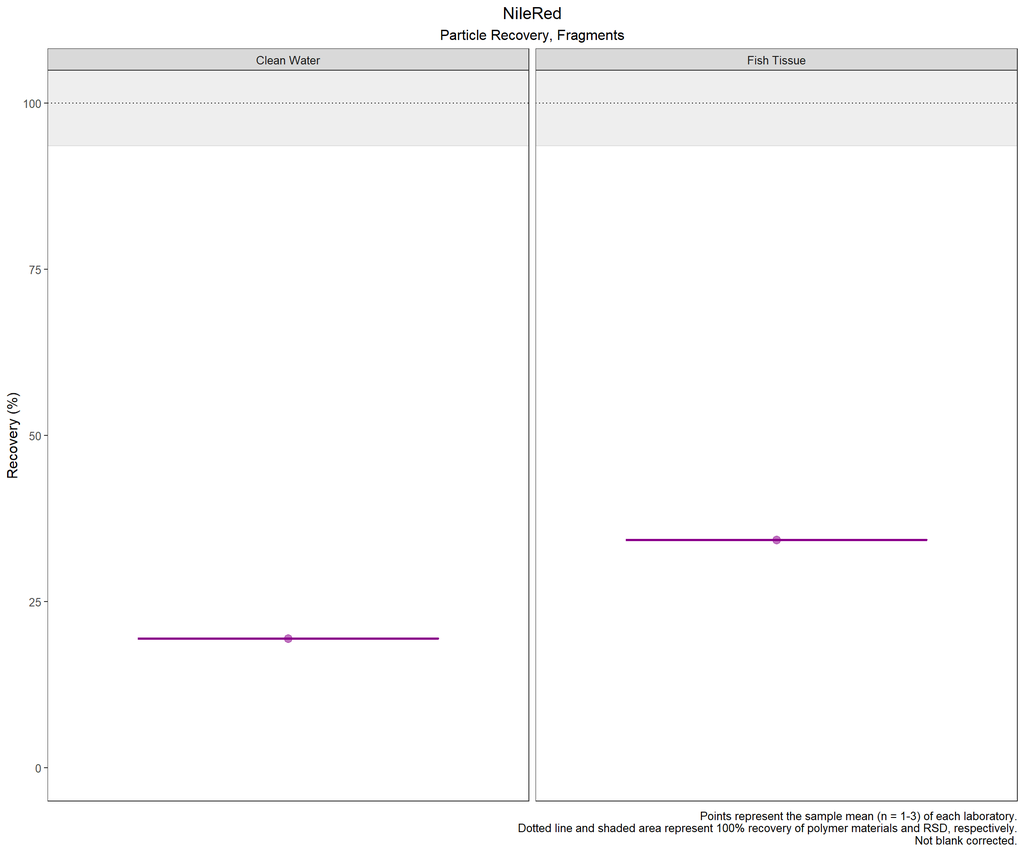

| Matrix | Lab ID | Sample ID | Morphology | Recovery |
| --- | --- | --- | --- | --- |
| Clean Water | N | N_CW_1 | Fiber | 80.00 |
| Clean Water | N | N_CW_1 | Fragment | 15.63 |
| Clean Water | N | N_CW_1 | Sphere | 125.00 |
| Clean Water | N | N_CW_2 | Fiber | 35.00 |
| Clean Water | N | N_CW_2 | Fragment | 20.07 |
| Clean Water | N | N_CW_2 | Sphere | 645.09 |
| Clean Water | N | N_CW_3 | Fiber | 75.00 |
| Clean Water | N | N_CW_3 | Fragment | 22.74 |
| Clean Water | N | N_CW_3 | Sphere | 720.98 |
| Fish Tissue | CC | CC_FT_1 | Fiber | 60.00 |
| Fish Tissue | CC | CC_FT_1 | Fragment | 32.32 |
| Fish Tissue | CC | CC_FT_1 | Sphere | 66.96 |
| Fish Tissue | CC | CC_FT_2 | Fiber | 5.00 |
| Fish Tissue | CC | CC_FT_2 | Fragment | 25.15 |
| Fish Tissue | CC | CC_FT_2 | Sphere | 48.03 |
| Fish Tissue | CC | CC_FT_3 | Fragment | 45.36 |
| Fish Tissue | CC | CC_FT_3 | Sphere | 35.71 |

NileRed: Total Particle Recovery by Morphology. Summary statistics by laboratory (n = 1-3 samples). Not blank corrected.

| Matrix | Lab ID | Morphology | Mean (%) | Median (%) | SD (%) | Min (%) | Max (%) |
| --- | --- | --- | --- | --- | --- | --- | --- |
| Fish Tissue | CC | Fiber | 32.50 | 32.50 | 38.89 | 5.00 | 60.00 |
| Fish Tissue | CC | Fragment | 34.28 | 32.32 | 10.24 | 25.15 | 45.36 |
| Fish Tissue | CC | Sphere | 50.24 | 48.03 | 15.74 | 35.71 | 66.96 |
| Clean Water | N | Fiber | 63.33 | 75.00 | 24.66 | 35.00 | 80.00 |
| Clean Water | N | Fragment | 19.48 | 20.07 | 3.59 | 15.63 | 22.74 |
| Clean Water | N | Sphere | 497.02 | 645.09 | 324.41 | 125.00 | 720.98 |

NileRed: Total Particle Recovery by Morphology. Summary statistics across all laboratories. Not blank corrected.

| Matrix | Morphology | Mean (%) | Median (%) | SD (%) | Min (%) | Max (%) |
| --- | --- | --- | --- | --- | --- | --- |
| Fish Tissue | Fiber | 32.50 | 32.50 | 38.89 | 5.00 | 60.00 |
| Fish Tissue | Fragment | 34.28 | 32.32 | 10.24 | 25.15 | 45.36 |
| Fish Tissue | Sphere | 50.24 | 48.03 | 15.74 | 35.71 | 66.96 |
| Clean Water | Fiber | 63.33 | 75.00 | 24.66 | 35.00 | 80.00 |
| Clean Water | Fragment | 19.48 | 20.07 | 3.59 | 15.63 | 22.74 |
| Clean Water | Sphere | 497.02 | 645.09 | 324.41 | 125.00 | 720.98 |

### 3.1.4 Morphology within Size Fraction

The following plots display the recovery (reported count/spiked count (%)) obtained from microscopy with nile red. **Reported particle characteristics must match expected particle characteristics of the spiking materials to count towards recovery estimations.** For example, the morphologies of polymer spiking materials are defined as spheres, fragments, and fibers. Morphologies outside of these definitions are currently excluded from analysis.

The dotted line is at 100% and the grey area represents the mean RSD for each given category. The data are **not** blank corrected.

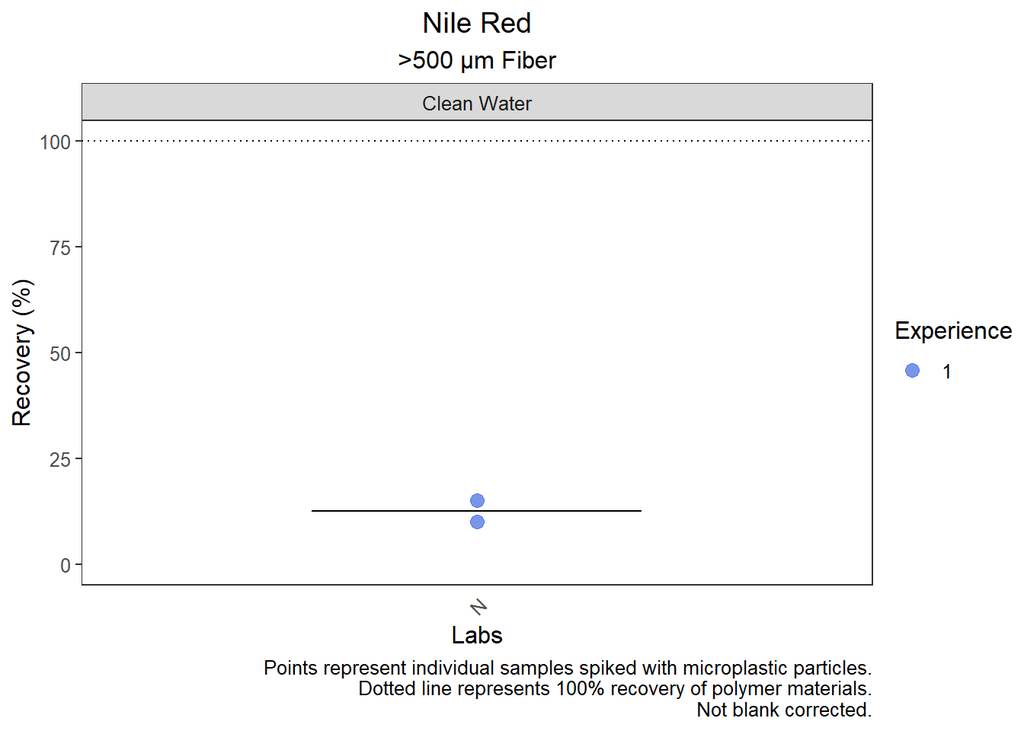

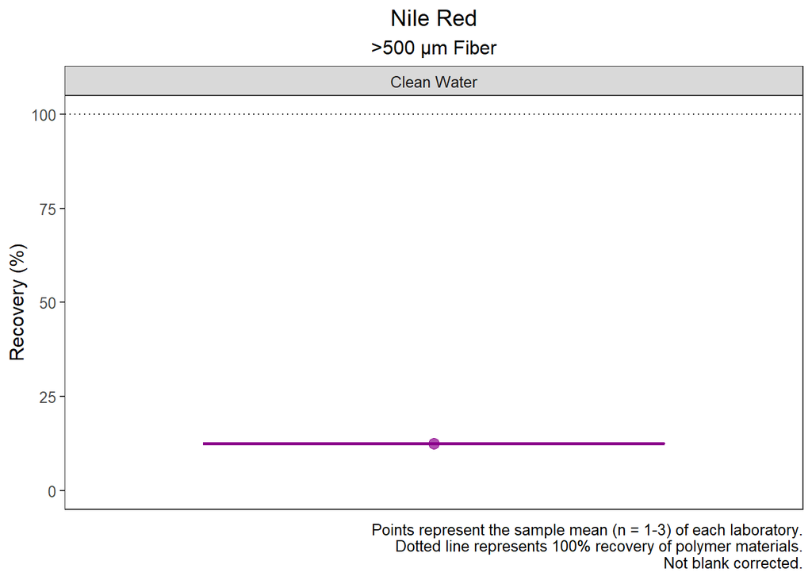

>500 µm Fiber

| Matrix | Lab ID | Sample ID | Recovery |
| --- | --- | --- | --- |
| Clean Water | N | N_CW_1 | 15 |
| Clean Water | N | N_CW_3 | 10 |

>500 µm Fiber

| Matrix | Lab ID | Mean (%) | Median (%) | SD (%) | Min (%) | Max (%) |
| --- | --- | --- | --- | --- | --- | --- |
| Clean Water | N | 12.5 | 12.5 | 3.54 | 10 | 15 |

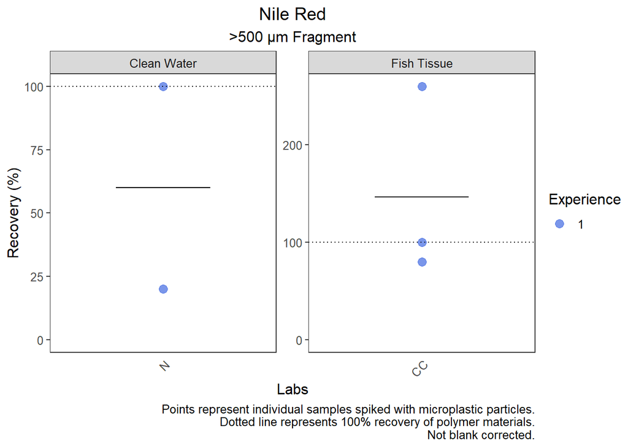

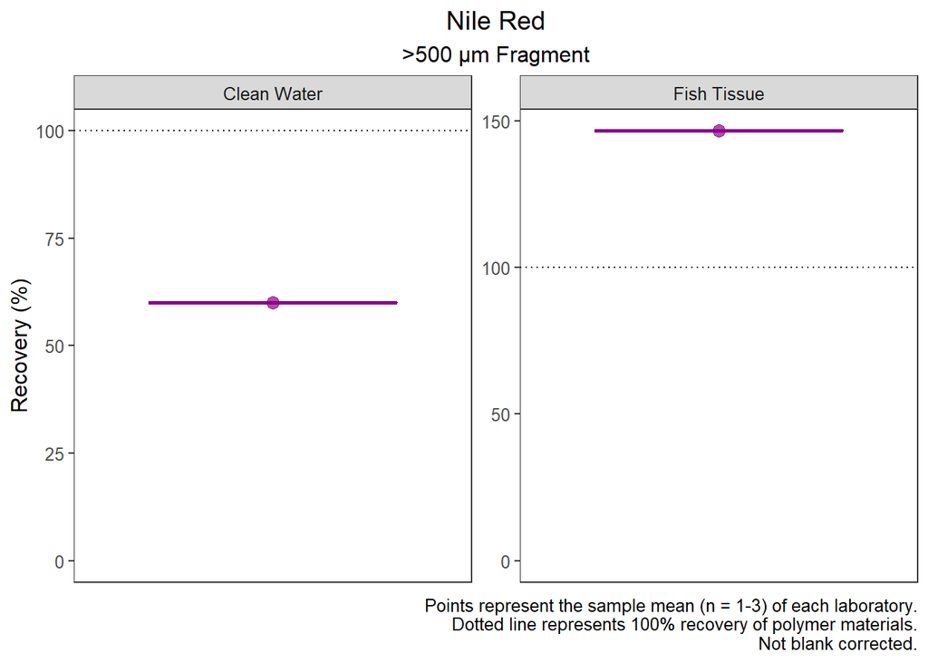

>500 µm Fragment

| Matrix | Lab ID | Sample ID | Recovery |
| --- | --- | --- | --- |
| Fish Tissue | CC | CC_FT_1 | 80 |
| Fish Tissue | CC | CC_FT_2 | 260 |
| Fish Tissue | CC | CC_FT_3 | 100 |
| Clean Water | N | N_CW_1 | 100 |
| Clean Water | N | N_CW_3 | 20 |

>500 µm Fragment

| Matrix | Lab ID | Mean (%) | Median (%) | SD (%) | Min (%) | Max (%) |
| --- | --- | --- | --- | --- | --- | --- |
| Fish Tissue | CC | 146.67 | 100 | 98.66 | 80 | 260 |
| Clean Water | N | 60.00 | 60 | 56.57 | 20 | 100 |

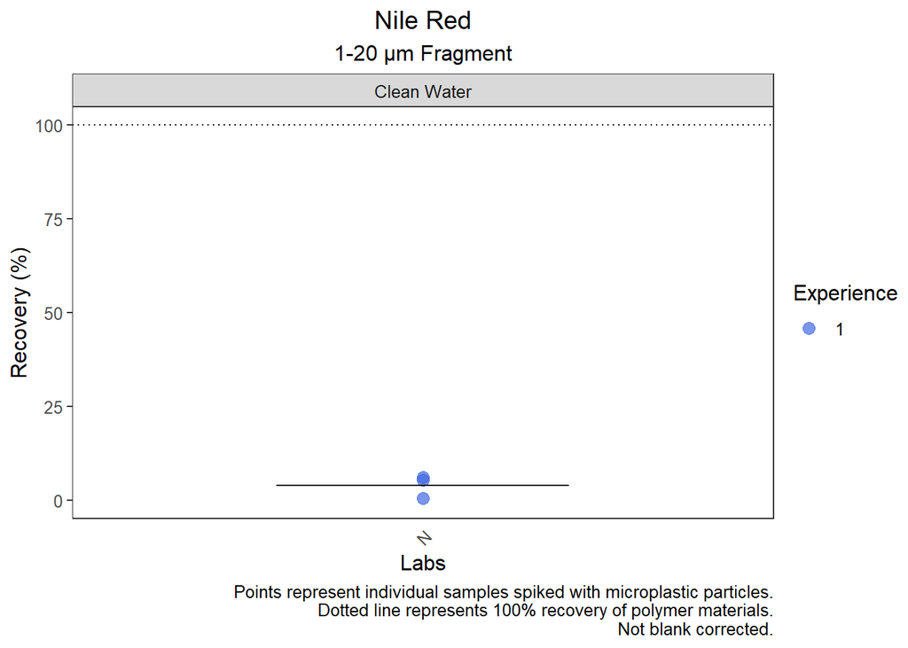

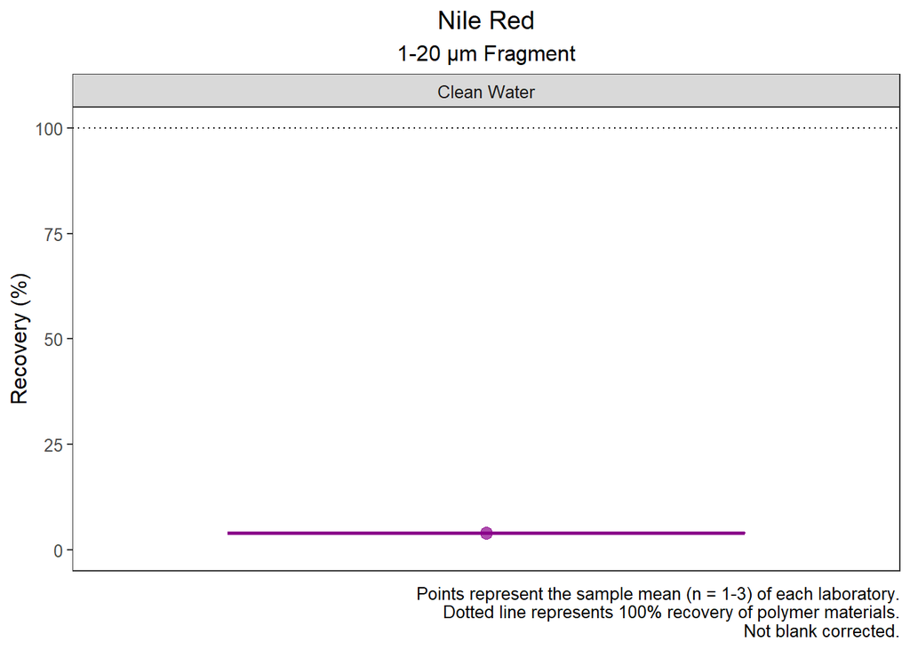

1-20 µm Fragment

| Matrix | Lab ID | Sample ID | Recovery |
| --- | --- | --- | --- |
| Clean Water | N | N_CW_1 | 0.56 |
| Clean Water | N | N_CW_2 | 6.11 |
| Clean Water | N | N_CW_3 | 5.28 |

1-20 µm Fragment

| Matrix | Lab ID | Mean (%) | Median (%) | SD (%) | Min (%) | Max (%) |
| --- | --- | --- | --- | --- | --- | --- |
| Clean Water | N | 3.98 | 5.28 | 3 | 0.56 | 6.11 |

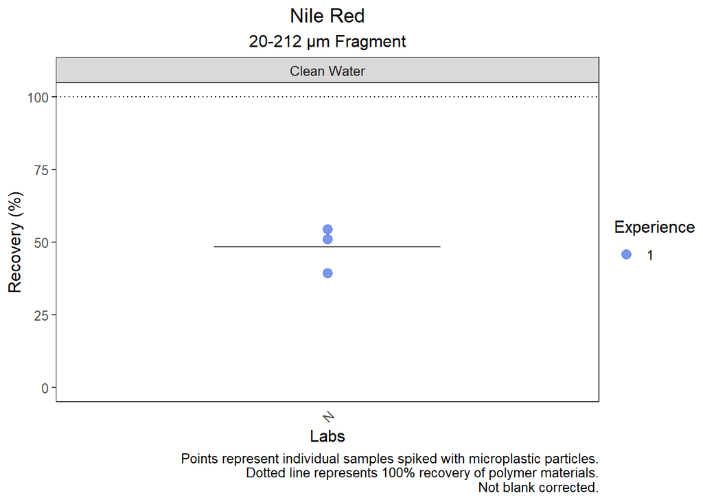